# Model fitting

PCB 6455 / BSC 4933: Biometry | Lecture 19

Dr. Brian Maitner

## Today’s agenda

- R has found the bottom of every NLL curve for us. **How?**
- Trying every value, and why that stops working
- Three ways to walk downhill: **Nelder-Mead, BFGS, simulated annealing**
- How to tell whether a fit **actually worked**, and whether it **fits the data**
- A challenge: who can get the **best fit**?

Type and run on a code block: type it into your script and run it. Code without the label is there to watch.

## The story so far

- **Lower NLL = better fit.** The best estimate is the bottom of the curve
- Intervals and model comparisons read the **shape** of that curve
- **Today:** how R finds the bottom in the first place, and how to tell when it did not

## Why does R need an algorithm at all?

Sometimes the bottom has a formula. For 52 routes occupied out of 71, the best $p$ is just $52 / 71$.

For the logistic decline,

$$p_t = \frac{1}{1 + e^{-(a + bt)}}$$

**there is no formula** for the best $a$ and $b$. The only way to find them is to **search**: try values, see which give a lower NLL, and try again.

An optimizer is a **search strategy**. The `method` argument chooses which one.

## Get set up

```r
library(bbmle)
library(biometrydata)

occ <- bobwhite_occupancy

# the occupancy model, with both parameters in one vector, as optim() wants
occ_nll <- function(p){
  prob <- plogis(p[1] + p[2] * occ$elapsed)
  -sum(dbinom(occ$n_occupied, size = occ$n_routes, prob = prob, log = TRUE))
}

occ_nll(c(2, -0.05))    # one guess: how good is it?
```

**Check:** about 59.8. The best possible, from Lecture 16, is 56.69.

# Trying every value

## Brute force

The simplest strategy: lay a **grid** over the surface and score every point.

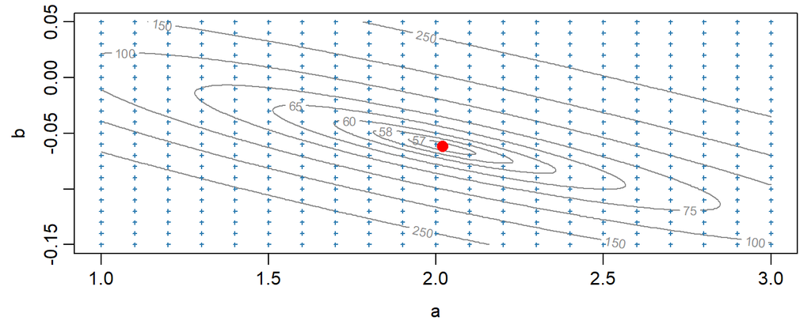

Blue crosses: a sample of the grid, every tenth point in each direction. The real one has **40,401** points.

## Your turn: brute force

```r
a_vec <- seq(1, 3, by = 0.01)
b_vec <- seq(-0.15, 0.05, by = 0.001)
grid <- expand.grid(a = a_vec, b = b_vec)    # every combination
nrow(grid)

grid_time <- system.time({
  grid$nll <- NA
  for (i in 1:nrow(grid)) {
    grid$nll[i] <- occ_nll(c(grid$a[i], grid$b[i]))
  }
})
grid_time

grid[which.min(grid$nll), ]                  # the best grid point
```

**Check:** best $a$ = 2.02, $b$ = -0.062, against 2.018 and -0.0619 from `optim()`.

## How slow is slow?

|  | Evaluations | Time |
| --- | --- | --- |
| brute force, 2 parameters | 40,401 | 4.5 seconds |
| `optim()`, 2 parameters | 75 | 4.9 thousandths of a second |

With **100 values per parameter**, brute force needs $100^k$ evaluations:

| Parameters | Evaluations | Time |
| --- | --- | --- |
| 2 | 10 thousand | 1.1 seconds |
| 4 | 100 million | 3.1 hours |
| **6** | **1 trillion** | **3.5 years** |

Trying every value works for one or two parameters. Beyond that, it would outlast the semester, and then the degree.

# Walking downhill

## Three strategies

Every method starts at a guess and moves **downhill**. They differ in how they choose the next step:

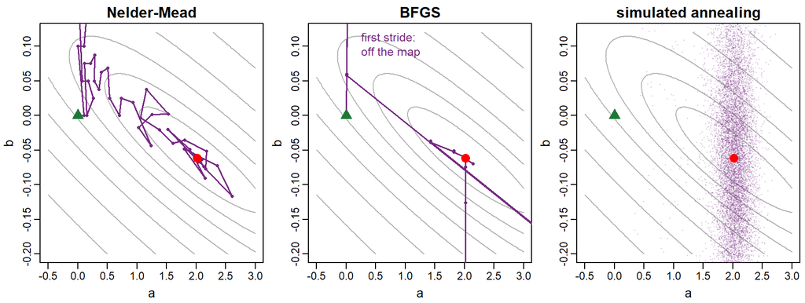

Green: the start. Red: the bottom. Purple: **every point each method tried**.

## Nelder-Mead

A **triangle** of three guesses tumbles downhill. Each step, the worst corner is flipped across the other two; the triangle stretches when that works and shrinks when it does not.

- Needs **only the NLL itself**, no slopes
- Copes with rough or awkward surfaces
- **`optim()`’s default**

Keep the best guesses, replace the worst one, repeat until the guesses stop improving.

## BFGS

Uses the **slope** of the surface, and how the slope is changing, to aim straight for the bottom.

- **Fast** when the surface is well behaved: fewer evaluations
- Needs a surface with **no corners or cliffs**, and a start that is not absurd
- **`mle2()`’s default**

Look at which way is downhill and how steeply, then take a long stride in that direction.

## Your turn: two methods

```r
fit_nm   <- optim(c(0, 0), occ_nll)                    # Nelder-Mead, the default
fit_bfgs <- optim(c(0, 0), occ_nll, method = "BFGS")

fit_nm$par;   fit_nm$value;   fit_nm$counts
fit_bfgs$par; fit_bfgs$value; fit_bfgs$counts
```

**Same answer? Which needed fewer evaluations?**

|  | $a$ | $b$ | NLL | evaluations |
| --- | --- | --- | --- | --- |
| Nelder-Mead | 2.0179 | -0.0619 | 56.688 | 75 |
| BFGS | 2.0177 | -0.0619 | 56.688 | 45 + 9 slopes |

## Simulated annealing

Takes **random** steps, and sometimes accepts one that goes **uphill**. Accepts fewer uphill steps as it “cools”.

- Can escape a **false bottom**, a dip that is not the lowest point
- **Slow**: always 10,000 evaluations here
- **Random**: a different answer every run, unless you `set.seed()`

Wander widely at first so you do not get stuck in the wrong valley, then settle down.

## Your turn: annealing twice

```r
set.seed(1)
fit_sa1 <- optim(c(0, 0), occ_nll, method = "SANN")

set.seed(2026)
fit_sa2 <- optim(c(0, 0), occ_nll, method = "SANN")

fit_sa1$par; fit_sa1$value
fit_sa2$par; fit_sa2$value
```

**Do the two runs agree? How close are they to BFGS?**

Close, not identical: NLLs of 56.689 and 56.691, against 56.688. A common habit is to **anneal first, then polish** with BFGS, starting from where annealing stopped.

## Two specialists you have already used

| Method | For | Where you met it |
| --- | --- | --- |
| `"L-BFGS-B"` | BFGS with **bounds** on each parameter | Lecture 16, keeping `size` positive |
| `optimize()` | **one** parameter only | Lecture 15, the single-$p$ fits |

`mle2()` takes the same names: `mle2(..., method = "Nelder-Mead")`.

# Did it work?

## A fit can fail without an error

```r
fit_cg <- optim(c(0, 0), occ_nll, method = "CG")    # another method optim() offers

fit_cg$par
fit_cg$value
fit_cg$convergence
```

$a$ = 1.154, $b$ = -0.0062, NLL **81.5**, against 56.7 at the true bottom. **No error. No warning.**

The only clue: `convergence` is **1**, not 0. It ran out of steps before it got there.

# Surfaces that are hard to search

## A false bottom you cannot see from inside

Lecture 16’s practice problem: reef fish richness **peaks at some depth**, a hump with a height, a location and a **width**. The NLL as the width changes, with the other parameters re-fitted at each width:

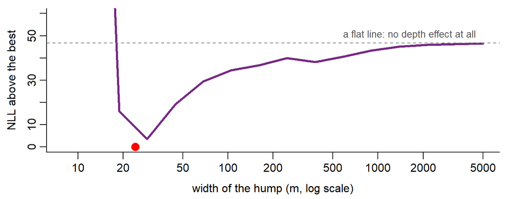

A wide enough hump **is** a flat line. Out there the NLL stops changing, so a downhill method sees **no slope** and stops, reporting success.

## What makes a surface hard to search

| The surface has | What goes wrong | Usual fix |
| --- | --- | --- |
| a **plateau**: a parameter stops mattering (the hump’s width) | no slope, so it stops and reports success | better starts, bounds, or a simpler model |
| **several dips**: rival explanations fit almost as well | stops in whichever dip is nearest | many starts, or simulated annealing |
| a **ridge**: two parameters that trade off | zigzags slowly along the valley | re-parameterize (Thursday) |
| a **cliff**: an `if` or a penalty in the code | BFGS needs a slope, and there is none at a cliff | Nelder-Mead, or rewrite the model |

Each kind of trouble has its own fix, so the first job is to notice which one you have.

## Check: start from many places

```r
reef <- reef_surveys

# p[1] log of the peak richness, p[2] depth of the peak (m),
# p[3] log of the width (m), p[4] log of the negative binomial size
reef_nll <- function(p){
  mu <- exp(p[1]) * exp(-(reef$depth - p[2])^2 / (2 * exp(p[3])^2))
  -sum(dnbinom(reef$richness, mu = mu, size = exp(p[4]), log = TRUE))
}

set.seed(19)
results <- NULL
for (i in 1:10) {
  start <- c(log(runif(1, 5, 50)), runif(1, 0, 30), log(runif(1, 1, 50)), log(runif(1, 1, 20)))
  fit <- optim(start, reef_nll)
  results <- rbind(results, c(peak = exp(fit$par[1]), depth = fit$par[2],
                              width = exp(fit$par[3]), nll = fit$value,
                              convergence = fit$convergence))
}
round(results, 1)
```

## What ten starts found

| peak | depth | width | nll | convergence |
| --- | --- | --- | --- | --- |
| 24.7 | 16.1 | 24.2 | 31752.3 | 0 |
| 24.7 | 16.1 | 24.2 | 31752.3 | 0 |
| 24.7 | 16.1 | 24.2 | 31752.3 | 0 |
| 24.7 | 16.1 | 24.2 | 31752.3 | 0 |
| 24.7 | 16.1 | 24.2 | 31752.3 | 0 |
| 24.7 | 16.1 | 24.2 | 31752.3 | 0 |
| 24.4 | 23.9 | 47.0 | 31775.9 | 0 |
| 24.4 | 26.0 | 52.8 | 31778.7 | 0 |
| 24.5 | 31.0 | 65.9 | 31782.5 | 0 |
| 23.5 | 2.8 | 13416.1 | 31799.0 | 0 |

**6 of 10** reach the best NLL; the rest stop up to 47 worse. **All** report `convergence = 0`.

## More parameters: harder to search

| Model | Parameters | Random starts that found the best fit |
| --- | --- | --- |
| bobwhite occupancy | 2 | **10 of 10** |
| reef hump | 4 | **6 of 10** |

Why more parameters make the search harder:

- You **cannot look** at a surface with more than two parameters
- More chances for parameters to **trade off**, making ridges and plateaus
- More room for **false bottoms**, so you need **more starts** to trust an answer

# Does the model fit the data?

## Draw the fit over the data

```r
# richness averaged in 2 m depth bins: 8,560 surveys are too many to read
bins <- cut(reef$depth, breaks = seq(0, 32, by = 2))
plot(tapply(reef$depth, bins, mean), tapply(reef$richness, bins, mean),
     pch = 16, xlab = "depth (m)", ylab = "mean species richness")

hump <- function(d, row){
  results[row, "peak"] * exp(-(d - results[row, "depth"])^2 / (2 * results[row, "width"]^2))
}
best <- which.min(results[, "nll"])
worst <- which.max(results[, "nll"])
curve(hump(x, best), add = TRUE, col = "red", lwd = 3)
curve(hump(x, worst), add = TRUE, col = "grey50", lwd = 3, lty = 2)
```

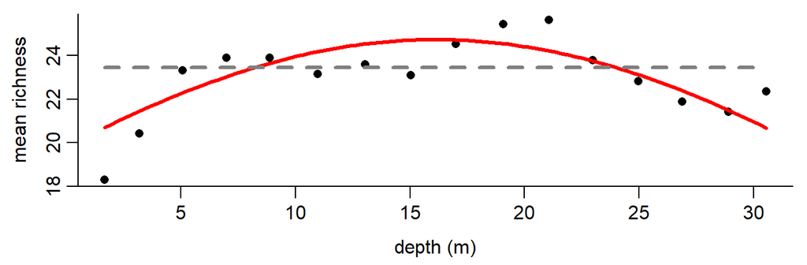

## Simulate from the fit

**If the model were true, would it produce data like ours?**

```r
fit_occ <- optim(c(2, -0.05), occ_nll, method = "BFGS")
p_fit <- plogis(fit_occ$par[1] + fit_occ$par[2] * occ$elapsed)

# 1,000 imaginary sets of surveys, from the fitted model
fake <- replicate(1000, rbinom(nrow(occ), size = occ$n_routes, prob = p_fit) / occ$n_routes)
lower <- apply(fake, 1, quantile, 0.025)    # the middle 95% of the fakes,
upper <- apply(fake, 1, quantile, 0.975)    # year by year

plot(occ$year, occ$n_occupied / occ$n_routes, pch = 16, ylim = c(0.5, 1),
     xlab = "year", ylab = "fraction of routes occupied")
lines(occ$year, lower, lty = 2)
lines(occ$year, upper, lty = 2)
```

[output not shown]

**Check:** 23 of 23 real years fall inside the band.

## Checking a fit

1. **`convergence` is 0.** With `mle2()`, no warning about convergence
2. **Several starts agree.** Report the lowest NLL; more parameters, more starts
3. **The fitted curve goes through the data.** Draw it
4. **Data simulated from the fit look like the real data**
5. **A bigger model never fits worse than a smaller one nested in it.** If it does, it has not found its bottom

Never trust a fit just because R returned numbers. Check that it stopped for the right reason, and that it agrees with itself.

## Which method, when

| Method | Use it when | Watch out for |
| --- | --- | --- |
| brute force | 1 or 2 parameters, or to find a starting point | impossibly slow beyond that |
| Nelder-Mead | the default; awkward surfaces | slower than BFGS |
| BFGS | no corners or cliffs; `mle2()`’s default | can fail from a bad start |
| L-BFGS-B | parameters need bounds |  |
| simulated annealing | several dips; nothing else works | slow, random: `set.seed()` |

**Whatever you use: check `convergence`.**

# Challenge

## Challenge: who can get the lowest NLL?

**Does development hurt bobwhite only past a threshold?** Counts stay flat until a route is $t$ developed, then fall:

$$\mu = \mu_0 \, e^{\,b \cdot \max(0,\; u - t)} \qquad \text{count} \sim \text{NegBin}(\mu, k)$$

```r
counts <- bobwhite_counts

# p[1] log mu0, p[2] slope b, p[3] threshold t (fraction developed), p[4] log k
threshold_nll <- function(p){
  mu <- exp(p[1] + p[2] * pmax(0, counts$frac_built - p[3]))
  -sum(dnbinom(counts$count, mu = mu, size = exp(p[4]), log = TRUE))
}

start <- c(2, -1, 0.3, 0)
first_try <- optim(start, threshold_nll)
first_try$value
```

**Beat it.** Any method, any start, any trick from today. Write down your lowest NLL, and **how** you got it.

## How the room could have won

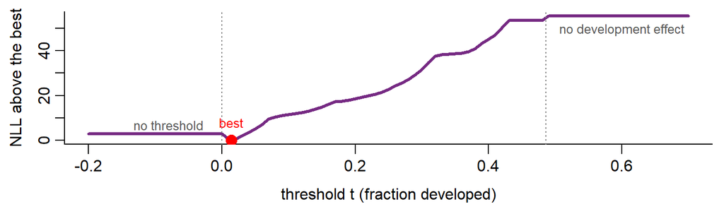

| Approach | NLL |
| --- | --- |
| `optim()` from the given start | 4574.15 (threshold below zero) |
| 20 random starts | best 4571.33; 12 stuck on a plateau |
| **bounds**: `L-BFGS-B`, $t$ from 0 to 0.48 | **4571.33** |
| **grid over $t$**, then polish | **4571.33** |

## What the best fit says

- Best threshold: **1.4%** developed. Effectively **no safe level**: counts fall from the first few percent
- The threshold model beats the plain development model by **2.8** NLL units, for one extra parameter: AIC prefers it by 3.6

The fitting problem and the biology agree: there is a threshold, and it is so close to zero that it barely matters.

## Before next class

Read Bolker **7.4**

Next time: **when fitting goes wrong**, and what to do about it